# INTRODUCTION

In this project, we will deal with the prediction of car prices, based on their characteristics, using multiple regression.

# LIBRARIES IMPORT

```python
import pandas as pd
import numpy as np
import matplotlib.pyplot as plt
import seaborn as sns
import statsmodels.api as sm

from sklearn.model_selection import train_test_split
from sklearn.linear_model import LinearRegression
from sklearn.metrics import mean_squared_error
from statsmodels.stats.outliers_influence import variance_inflation_factor
from IPython import display


%matplotlib inline
```

# DATA IMPORT

```python
data = pd.read_csv('CarPrice_Assignment.csv', usecols = ['price', 'wheelbase', 'carlength', 'carwidth', 'carheight','curbweight', 'enginesize', 'boreratio', 'stroke', 'horsepower','peakrpm', 'citympg', 'highwaympg'])
```

# DATA MEANING

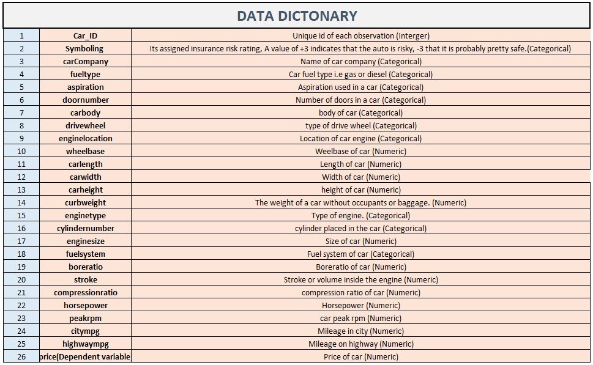

```python
display.Image("dict.jpg")
```

```python
data.info()
```

```
<class 'pandas.core.frame.DataFrame'>
RangeIndex: 205 entries, 0 to 204
Data columns (total 13 columns):
 #   Column      Non-Null Count  Dtype
---  ------      --------------  -----
 0   wheelbase   205 non-null    float64
 1   carlength   205 non-null    float64
 2   carwidth    205 non-null    float64
 3   carheight   205 non-null    float64
 4   curbweight  205 non-null    int64
 5   enginesize  205 non-null    int64
 6   boreratio   205 non-null    float64
 7   stroke      205 non-null    float64
 8   horsepower  205 non-null    int64
 9   peakrpm     205 non-null    int64
 10  citympg     205 non-null    int64
 11  highwaympg  205 non-null    int64
 12  price       205 non-null    float64
dtypes: float64(7), int64(6)
memory usage: 20.9 KB
```

# DATA EXPLORATION

```python
data.head(5)
```

|  | wheelbase | carlength | carwidth | carheight | curbweight | enginesize | boreratio | stroke | horsepower | peakrpm | citympg | highwaympg | price |
| --- | --- | --- | --- | --- | --- | --- | --- | --- | --- | --- | --- | --- | --- |
| 0 | 88.6 | 168.8 | 64.1 | 48.8 | 2548 | 130 | 3.47 | 2.68 | 111 | 5000 | 21 | 27 | 13495.0 |
| 1 | 88.6 | 168.8 | 64.1 | 48.8 | 2548 | 130 | 3.47 | 2.68 | 111 | 5000 | 21 | 27 | 16500.0 |
| 2 | 94.5 | 171.2 | 65.5 | 52.4 | 2823 | 152 | 2.68 | 3.47 | 154 | 5000 | 19 | 26 | 16500.0 |
| 3 | 99.8 | 176.6 | 66.2 | 54.3 | 2337 | 109 | 3.19 | 3.40 | 102 | 5500 | 24 | 30 | 13950.0 |
| 4 | 99.4 | 176.6 | 66.4 | 54.3 | 2824 | 136 | 3.19 | 3.40 | 115 | 5500 | 18 | 22 | 17450.0 |

```python
data.count()
```

```
wheelbase     205
carlength     205
carwidth      205
carheight     205
curbweight    205
enginesize    205
boreratio     205
stroke        205
horsepower    205
peakrpm       205
citympg       205
highwaympg    205
price         205
dtype: int64
```

# CHECK FOR MISSING VALUES

```python
pd.isnull(data).any()
```

```
wheelbase     False
carlength     False
carwidth      False
carheight     False
curbweight    False
enginesize    False
boreratio     False
stroke        False
horsepower    False
peakrpm       False
citympg       False
highwaympg    False
price         False
dtype: bool
```

```python
pd.isna(data).any()
```

```
wheelbase     False
carlength     False
carwidth      False
carheight     False
curbweight    False
enginesize    False
boreratio     False
stroke        False
horsepower    False
peakrpm       False
citympg       False
highwaympg    False
price         False
dtype: bool
```

### We didn't find any missing values

# Visualising data

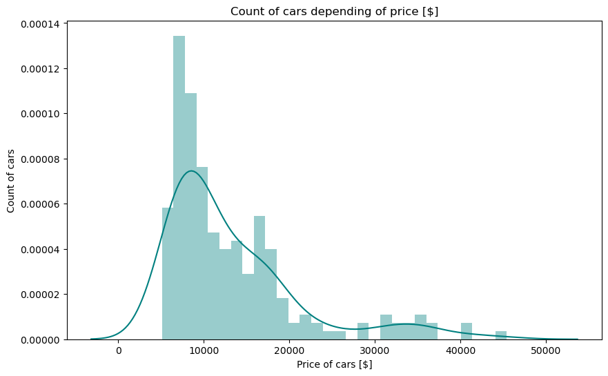

```python
# price distribution
plt.figure(figsize=(10,6))
sns.distplot(data['price'], bins = 30, hist=True, kde=True, color='teal')

plt.xlabel('Price of cars [$]')
plt.ylabel('Count of cars')
plt.title('Count of cars depending of price [$]')
plt.show()
```

# CORRELATION

```
correlation is really the most important for us, because it is according to it that we determine which of the predictors will have essential contribution in the construction of our model, in addition, thanks to the correlation matrix we can deduce which predictors may be problems with, for example, by correlation with other predictors. It is worth adding that we take into account only constant variables.
```

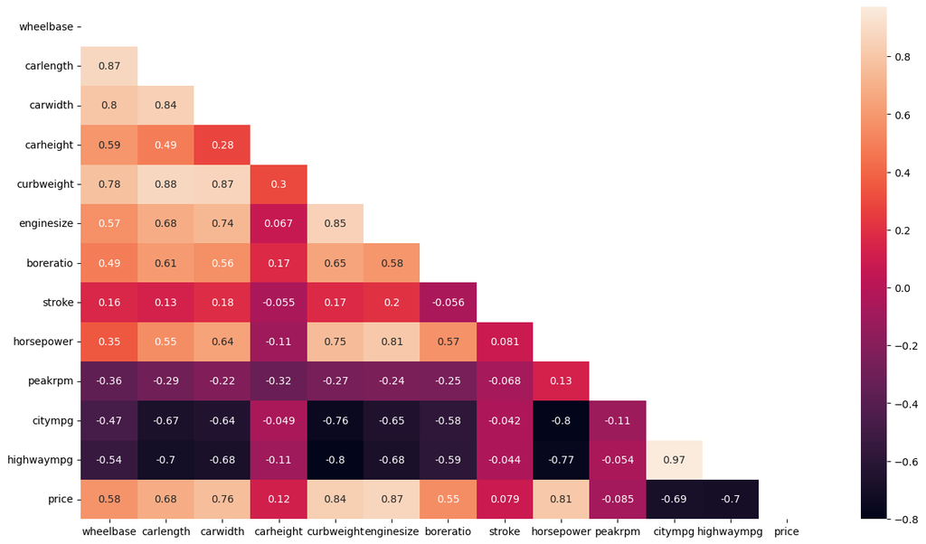

```python
data.corr() #PEARSON CORR

mask = np.zeros_like(data.corr())
triangle_indices = np.triu_indices_from(mask)
mask[triangle_indices] = True

plt.figure(figsize=(16,9))
sns.heatmap(data.corr(), mask=mask, annot=True, annot_kws={'size':10})
plt.xticks(fontsize=10)
plt.yticks(fontsize=10)
plt.show()
```

The most correlated with the price are data on car dimensions, kerb weight, engine size, cylinder diameter ratio, horsepower. On the other hand, the inverse correlation of Price occurs with combustion in the city and on the highway. Our predictors are strongly correlated, ( Especially the combustion variables are strongly inversely correlated with the rest of the variables) but at this stage we will not worry about it, but we will keep it in mind.

# Training & test dataset Split

```python
prices = data['price']
features = data.drop('price', axis=1)

X_train, X_test, Y_train, Y_test = train_test_split(features, prices,
                                                    test_size=0.2, random_state=10)
```

# MUTIVARIABLE REGRESSION

```python
X_incl_const = sm.add_constant(X_train)

regr = LinearRegression()
regr.fit(X_train, Y_train)

print('Training data r-squared:', regr.score(X_train, Y_train))
print('Test data r-squared:', regr.score(X_test, Y_test))

print('Intercept', regr.intercept_)
pd.DataFrame(data=regr.coef_, index=X_train.columns, columns = ['coef'])
```

```
Training data r-squared: 0.8793763232505996
Test data r-squared: 0.5198633550309353
Intercept -57371.81170306881
```

|  | coef |
| --- | --- |
| wheelbase | 30.000746 |
| carlength | -73.701694 |
| carwidth | 587.950504 |
| carheight | 282.488244 |
| curbweight | 2.965247 |
| enginesize | 132.770673 |
| boreratio | -2098.578333 |
| stroke | -3415.132634 |
| horsepower | 56.638392 |
| peakrpm | 1.881008 |
| citympg | -210.297615 |
| highwaympg | 332.763753 |

The match result on the test data is not satisfactory enough, so we will perform transformations.

# Transformations

```python
data['price'].skew() # data is 'tilted' to the right
```

```
1.7776781560914454
```

```python
price_log = np.log(data['price'])
price_log.skew()
```

```
0.672888533977329
```

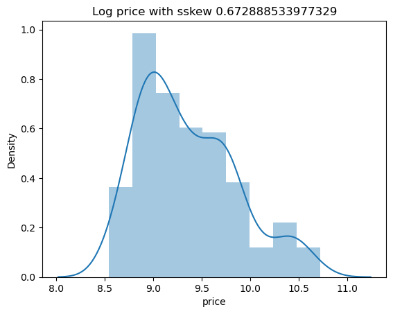

```python
sns.distplot(price_log)
plt.title(f'Log price with sskew {price_log.skew()}')
plt.show()
```

# REGRESSION using LOG

```python
prices = np.log(data['price']) #LOG PRICES
features = data.drop(['price'], axis=1)

X_train, X_test, Y_train, Y_test = train_test_split(features, prices,
                                                    test_size=0.2, random_state=10)

regr = LinearRegression()
regr.fit(X_train, Y_train)

print('Training data r-squared:', regr.score(X_train, Y_train))
print('Test data r-squared:', regr.score(X_test, Y_test))

print('Intercept', regr.intercept_)
pd.DataFrame(data=regr.coef_, index=X_train.columns, columns = ['coef'])
```

```
Training data r-squared: 0.8877936672190607
Test data r-squared: 0.6563834282017414
Intercept 4.551442359987347
```

|  | coef |
| --- | --- |
| wheelbase | -0.000999 |
| carlength | -0.000236 |
| carwidth | 0.036969 |
| carheight | 0.011116 |
| curbweight | 0.000402 |
| enginesize | 0.002689 |
| boreratio | -0.036564 |
| stroke | -0.118289 |
| horsepower | 0.004898 |
| peakrpm | 0.000060 |
| citympg | -0.023360 |
| highwaympg | 0.026900 |

the data matching on the test set has improved, but we can still work on improving the model.

```python
X_incl_const = sm.add_constant(X_train)

model = sm.OLS(Y_train, X_incl_const)
results = model.fit()

#results.params
#results.pvalues
pd.DataFrame({'coef': results.params,'pvalues': round(results.pvalues, 3)}) #OVER 0.05 NOT SIGNIFICANT
```

|  | coef | pvalues |
| --- | --- | --- |
| const | 4.551442 | 0.000 |
| wheelbase | -0.000999 | 0.870 |
| carlength | -0.000236 | 0.945 |
| carwidth | 0.036969 | 0.021 |
| carheight | 0.011116 | 0.198 |
| curbweight | 0.000402 | 0.000 |
| enginesize | 0.002689 | 0.003 |
| boreratio | -0.036564 | 0.636 |
| stroke | -0.118289 | 0.014 |
| horsepower | 0.004898 | 0.000 |
| peakrpm | 0.000060 | 0.155 |
| citympg | -0.023360 | 0.031 |
| highwaympg | 0.026900 | 0.008 |

as statistically useless we can consider wheelbase, carlenght, carheight, boreratio and peakrmp.

# TESTING FOR MULTICOLLINEARITY

```python
vif = [variance_inflation_factor(exog=X_incl_const, exog_idx = each) for each in range (X_incl_const.shape[1])]

pd.DataFrame({'coef': X_incl_const.columns, 'vif' : np.round(vif, 2)})
```

|  | coef | vif |
| --- | --- | --- |
| 0 | const | 5191.70 |
| 1 | wheelbase | 7.02 |
| 2 | carlength | 9.55 |
| 3 | carwidth | 5.57 |
| 4 | carheight | 2.19 |
| 5 | curbweight | 13.98 |
| 6 | enginesize | 6.72 |
| 7 | boreratio | 2.28 |
| 8 | stroke | 1.23 |
| 9 | horsepower | 9.01 |
| 10 | peakrpm | 1.99 |
| 11 | citympg | 25.29 |
| 12 | highwaympg | 24.67 |

In our case, there has been multicollinearity (VIF ~ 10), as a result, it will be necessary to get rid of some predictors.

# Model Simplification & Baysian Information Criterion

```python
#Original model with Log prices and all features
X_incl_const = sm.add_constant(X_train)

model = sm.OLS(Y_train, X_incl_const)
results = model.fit()

org_coef = pd.DataFrame({'coef': results.params,'pvalues': round(results.pvalues, 3)}) #OVER 0.05 NOT SIGNIFICANT

print('BIC is:',results.bic)
print('R-squared is:',results.rsquared)
```

```
BIC is: -47.52820236843377
R-squared is: 0.887793667219061
```

```python
X_incl_const = sm.add_constant(X_train)
X_incl_const = X_incl_const.drop(['carlength','wheelbase','boreratio','carheight','peakrpm','citympg'], axis=1)

model = sm.OLS(Y_train, X_incl_const)
results = model.fit()

coef_minus_indus = pd.DataFrame({'coef': results.params,'pvalues': round(results.pvalues, 3)}) #OVER 0.05 NOT SIGNIFICANT

print('BIC is:',results.bic) #lepsze
print('R-squared is:',results.rsquared)
```

```
BIC is: -67.8553627570098
R-squared is: 0.8805409287709034
```

```python
#Reduced model #1 excluding AGE

X_incl_const = sm.add_constant(X_train)
X_incl_const = X_incl_const.drop(['highwaympg','citympg','carlength'], axis=1)

model = sm.OLS(Y_train, X_incl_const)
results = model.fit()

coef_minus_age = pd.DataFrame({'coef': results.params,'pvalues': round(results.pvalues, 3)}) #OVER 0.05 NOT SIGNIFICANT

print('BIC is:',results.bic) #lepsze
print('R-squared is:',results.rsquared)
```

```
BIC is: -54.554620720322276
R-squared is: 0.881988077371485
```

After removing the strongly correlated variables and not significant variables, we got better results without losing the R-squared fit.

# RESIDUALS

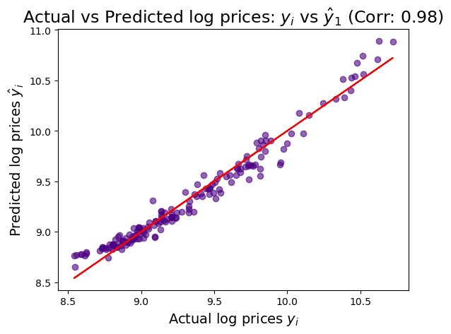

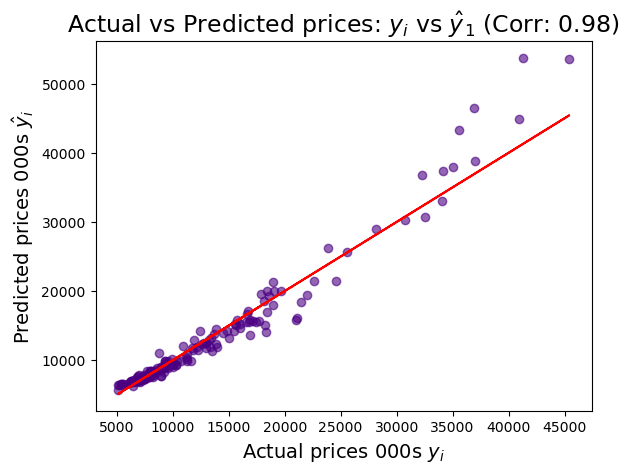

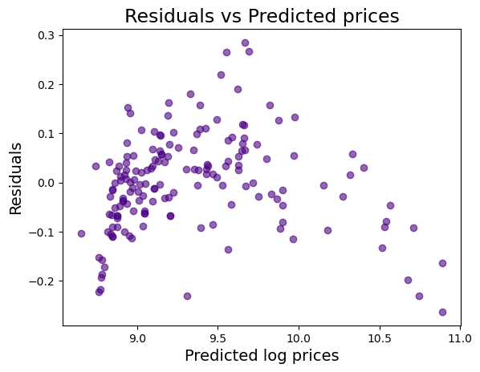

```python
# Modified model: transformed (using log prices) & simplified (droppint 3 features)

prices = np.log(data['price']) #LOG PRICES
features = data.drop(['carlength','wheelbase','boreratio','carheight','peakrpm','citympg'], axis=1)

X_train, X_test, Y_train, Y_test = train_test_split(features, prices,
                                                    test_size=0.2, random_state=10)

# Using Statsmodel
X_incl_const = sm.add_constant(X_train)
model = sm.OLS(Y_train, X_incl_const)
results = model.fit()

# Graph of Actual vs Predicter Prices
corr = round(Y_train.corr(results.fittedvalues), 2)
plt.scatter(x=Y_train,y=results.fittedvalues, c = 'indigo', alpha = 0.6)
plt.plot(Y_train,Y_train, color='red')
plt.xlabel('Actual log prices $y_i$', fontsize= 14)
plt.ylabel('Predicted log prices $\hat y_i$', fontsize= 14)
plt.title(f'Actual vs Predicted log prices: $y_i$ vs $ \hat y_1$ (Corr: {corr})',fontsize = 17)
plt.show()

plt.scatter(x=np.e**Y_train,y=np.e**results.fittedvalues, c = 'indigo', alpha = 0.6)
plt.plot(np.e**Y_train,np.e**Y_train, color='red')

plt.xlabel('Actual prices 000s $y_i$', fontsize= 14)
plt.ylabel('Predicted prices 000s $\hat y_i$', fontsize= 14)
plt.title(f'Actual vs Predicted prices: $y_i$ vs $ \hat y_1$ (Corr: {corr})',fontsize = 17)
plt.show()

# Residuals vs Predicted values
plt.scatter(x=results.fittedvalues,y=results.resid, c = 'indigo', alpha = 0.6)

plt.xlabel('Predicted log prices', fontsize= 14)
plt.ylabel('Residuals', fontsize= 14)
plt.title(f'Residuals vs Predicted prices',fontsize = 17)
plt.show()

# Mean Squared Error & R-Squared
reduced_log_mse = round(results.mse_resid, 3)
reduced_log_rsquared = round(results.rsquared, 3)
```

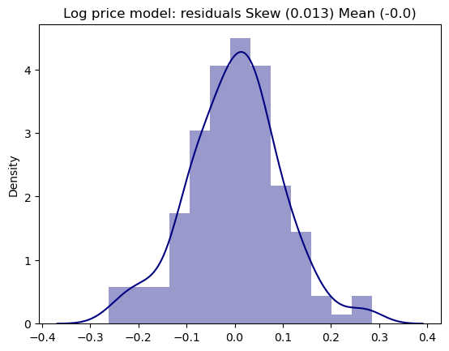

```python
# Distribution of Residuals (log prices) - checking for normality
resid_mean = round(results.resid.mean(), 3)
resid_skew = round(results.resid.skew(), 3)

sns.distplot(results.resid, color = 'navy')
plt.title(f'Log price model: residuals Skew ({resid_skew}) Mean ({resid_mean})')
```

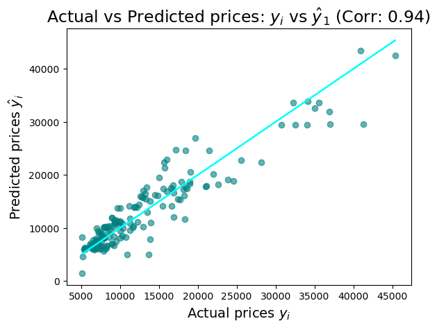

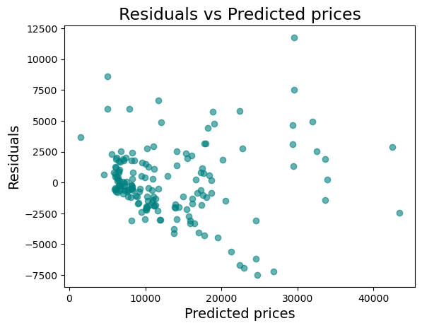

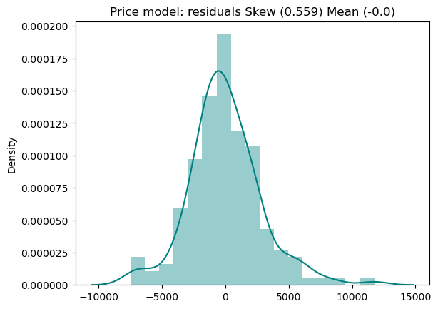

```python
#ORIGINAL DATA
prices = data['price']
features = data.drop('price', axis=1)

X_train, X_test, Y_train, Y_test = train_test_split(features, prices,
                                                    test_size=0.2, random_state=10)

# Using Statsmodel
X_incl_const = sm.add_constant(X_train)
model = sm.OLS(Y_train, X_incl_const)
results = model.fit()
corr = round(Y_train.corr(results.fittedvalues), 2)

# Predicted vs Actual prices
plt.scatter(x=Y_train,y=results.fittedvalues, c = 'teal', alpha = 0.6)
plt.plot(Y_train,Y_train, color='cyan')
plt.xlabel('Actual prices $y_i$', fontsize= 14)
plt.ylabel('Predicted prices $\hat y_i$', fontsize= 14)
plt.title(f'Actual vs Predicted prices: $y_i$ vs $ \hat y_1$ (Corr: {corr})',fontsize = 17)
plt.show()

# Residuals vs Prices
plt.scatter(x=results.fittedvalues,y=results.resid, c = 'teal', alpha = 0.6)

plt.xlabel('Predicted prices', fontsize= 14)
plt.ylabel('Residuals', fontsize= 14)
plt.title(f'Residuals vs Predicted prices',fontsize = 17)
plt.show()

# Distribution of Residuals (log prices) - checking for normality
resid_mean = round(results.resid.mean(), 3)
resid_skew = round(results.resid.skew(), 3)

sns.distplot(results.resid, color = 'teal')
plt.title(f'Price model: residuals Skew ({resid_skew}) Mean ({resid_mean})')


# Mean Squared Error & R-Squared
reduced_mse = round(results.mse_resid, 3)
reduced_rsquared = round(results.rsquared, 3)
```

```python
pd.DataFrame({'R-Squared':[reduced_log_rsquared,reduced_rsquared],
              'MSE':[reduced_log_mse,reduced_mse],
             'RMSE': np.sqrt([reduced_log_mse,reduced_mse])},
             index=['Reduced Log Model','Full Normal Price Model'])
```

|  | R-Squared | MSE | RMSE |
| --- | --- | --- | --- |
| Reduced Log Model | 0.964 | 0.010 | 0.100000 |
| Full Normal Price Model | 0.879 | 8691996.722 | 2948.219246 |

# BUILDING A TOOL

```python
features = data.drop(['carlength','wheelbase','boreratio','carheight','peakrpm','citympg','price'], axis=1)

log_prices = np.log(data['price'])
target = pd.DataFrame(log_prices, columns = ['price'])
```

```python
features.head(0)
```

|  | carwidth | curbweight | enginesize | stroke | horsepower | highwaympg |
| --- | --- | --- | --- | --- | --- | --- |

```python
carwidth_IDX = 0
curbweight_IDX = 1
enginesize_IDX = 2
stroke_IDX = 3
horsepower_IDX = 4
highwaympg_IDX = 5

car_stats = features.mean().values.reshape(1, 6)
```

```python
features.mean().values.shape
```

```
(6,)
```

```python
regr = LinearRegression().fit(features, target)
fitted_vals = regr.predict(features)

MSE = mean_squared_error(target, fitted_vals)
RMSE = np.sqrt(MSE)
```

```python
MSE
```

```
0.03582847413444062
```

```python
def get_log_estimate(width,
                    curbweight,
                    enginesize,
                    stroke,
                    horsepower,
                    highwaympg,
                    high_confidence=True):

    # Configure property
    car_stats[0][carwidth_IDX] = width
    car_stats[0][curbweight_IDX] = curbweight
    car_stats[0][enginesize_IDX] = enginesize
    car_stats[0][stroke_IDX] = stroke
    car_stats[0][horsepower_IDX] = horsepower
    car_stats[0][highwaympg_IDX] = highwaympg

    log_estimate = regr.predict(car_stats)[0][0]

     # Calc Range
    if high_confidence:
        upper_bound = log_estimate + 2*RMSE
        lower_bound = log_estimate - 2*RMSE
        interval = 95
    else:
        upper_bound = log_estimate + RMSE
        lower_bound = log_estimate - RMSE
        interval = 68

    return log_estimate, upper_bound, lower_bound, interval
```

```python
def get_dollar_estimate(width_,curb_weight,engine_size,stroke_,horse_power,highway_mpg,large_range):
    """Estimate the price of a car.

    Keyword arguments:
    width_ -- Width of the car
    curb_weight -- Vehicle weight
    engine_size -- Engine displacement
    stroke_ -- Piston stroke
    horse_power -- Number of horsepower
    highway_mpg -- Combustion on the highway
    large_range -- True for 95% prediction interval, False for a 68% prediction interval
    """




    log_est, upper, lower, conf,= get_log_estimate(width=width_,
                                                   curbweight = curb_weight,
                                                   enginesize = engine_size,
                                                   stroke = stroke_,
                                                   horsepower = horse_power,
                                                   highwaympg = highway_mpg,
                                                   high_confidence = large_range)
    #SCALE FACTOR
    dollar_est = np.e**log_est
    dollar_hi = np.e**upper
    dollar_low = np.e**lower

    #ROUND VALUES
    dollar_est = np.around(dollar_est, -3)
    dollar_hi = np.around(dollar_hi, -3)
    dollar_low = np.around(dollar_low, -3)

    print(f'Estimated price of house: {dollar_est}$\n Upper Bound: {dollar_hi}$\n Lower Bound: {dollar_low}$')
```

```python
get_dollar_estimate(70,2562,130,2.40,1000,1,True)
```

```
Estimated price of house: 553000.0$
 Upper Bound: 808000.0$
 Lower Bound: 379000.0$
```